# Zombies Homework 3

[figure not shown]

Aghhhhhh!

```r
library(curl)
library(dplyr)
library(sciplot)
library(manipulate)
library(ggplot2)
```

## Challenges

1. I had a very hard time coming up with and keeping track of the variables I was using. This homework had a lot of information, and it got overwhelming at times.
2. I also read that we could not find standard deviation for question 1 using the sd() function, so I did it manually at first - but it got me the same answer.
3. I had a hard time with my box plots on question 2, but after looking through the modules/googling my issue, I was able to figure it out.
4. For question 3, I originally thought I needed to put height/weight/age in one plot, so I was having a really hard time. I then realized we probably need one plot showing age vs. weight and one showing age vs. height and had to compare them.
5. Lastly, I had a hard time with the sample function. I found a function that worked: sample_n.

```r
f <- curl("https://raw.githubusercontent.com/fuzzyatelin/fuzzyatelin.github.io/master/AN588_Fall23/zombies.csv")
d <- read.csv(f, header = TRUE, sep = ",", stringsAsFactors = FALSE) #Assign D as the vector for the data set
head(d)
```

```
##   id first_name last_name gender   height   weight zombies_killed
## 1  1      Sarah    Little Female 62.88951 132.0872              2
## 2  2       Mark    Duncan   Male 67.80277 146.3753              5
## 3  3    Brandon     Perez   Male 72.12908 152.9370              1
## 4  4      Roger   Coleman   Male 66.78484 129.7418              5
## 5  5      Tammy    Powell Female 64.71832 132.4265              4
## 6  6    Anthony     Green   Male 71.24326 152.5246              1
##   years_of_education                           major      age
## 1                  1                medicine/nursing 17.64275
## 2                  3 criminal justice administration 22.58951
## 3                  1                       education 21.91276
## 4                  6                  energy studies 18.19058
## 5                  3                       logistics 21.10399
## 6                  4                  energy studies 21.48355
```

#### Assign Each Varible to a Vector (Excluding D because this is the Main Data Set)

```r
a <- d$height
b <- d$weight
c <- d$age
e <- d$zombies_killed
f <- d$years_of_education
```

## Question 1

```r
#Finding the Mean
mean(a, na.rm=TRUE)
```

```
## [1] 67.6301
```

```r
mean(b, na.rm=TRUE)
```

```
## [1] 143.9075
```

```r
mean(c, na.rm=TRUE)
```

```
## [1] 20.04696
```

```r
mean(e, na.rm=TRUE)
```

```
## [1] 2.992
```

```r
mean(f, na.rm=TRUE)
```

```
## [1] 2.996
```

```r
#Finding Standard Deviation Step-By-Step
sqrt(sum((a-mean(a))^2/(length(a)-1)))
```

```
## [1] 4.310126
```

```r
sqrt(sum((b-mean(b))^2/(length(b)-1)))
```

```
## [1] 18.40106
```

```r
sqrt(sum((c-mean(c))^2/(length(c)-1)))
```

```
## [1] 2.965066
```

```r
sqrt(sum((e-mean(e))^2/(length(e)-1)))
```

```
## [1] 1.748426
```

```r
sqrt(sum((f-mean(f))^2/(length(f)-1)))
```

```
## [1] 1.676543
```

```r
#Finding the Standard Deviation with sd() Function
sd(d$height, na.rm=TRUE)
```

```
## [1] 4.310126
```

```r
sd(d$weight, na.rm=TRUE)
```

```
## [1] 18.40106
```

```r
sd(d$age, na.rm=TRUE)
```

```
## [1] 2.965066
```

```r
sd(d$zombies_killed, na.rm=TRUE)
```

```
## [1] 1.748426
```

```r
sd(d$years_of_education, na.rm=TRUE)
```

```
## [1] 1.676543
```

## Question 2

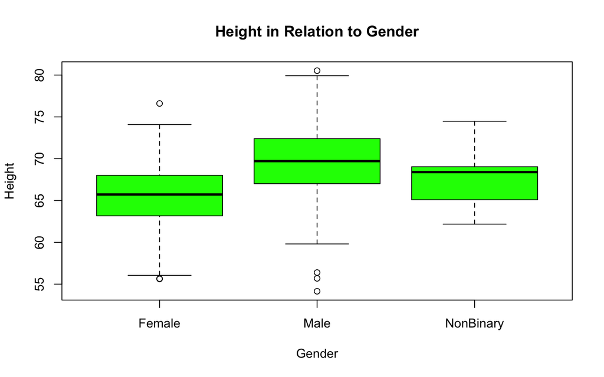

```r
boxplot(height ~ gender, d, col = "green", main = "Height in Relation to Gender", xlab = "Gender", ylab = "Height")
```

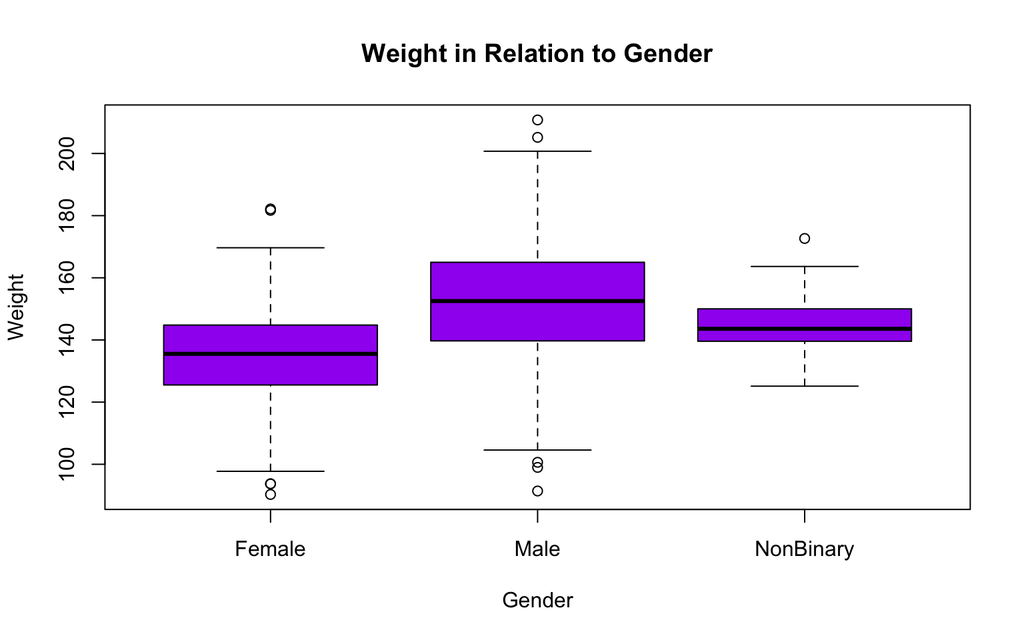

```r
boxplot(weight ~ gender, d, col = "purple", main = "Weight in Relation to Gender", xlab = "Gender", ylab = "Weight")
```

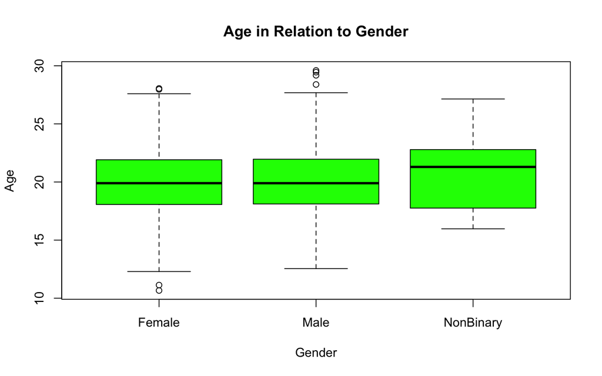

```r
boxplot(age ~ gender, d, col = "green", main = "Age in Relation to Gender", xlab = "Gender", ylab = "Age")
```

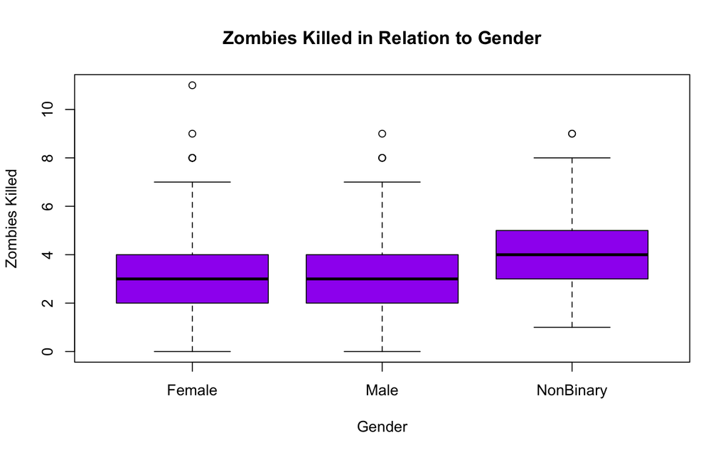

```r
boxplot(zombies_killed ~ gender, d, col = "purple", main = "Zombies Killed in Relation to Gender", xlab = "Gender", ylab = "Zombies Killed")
```

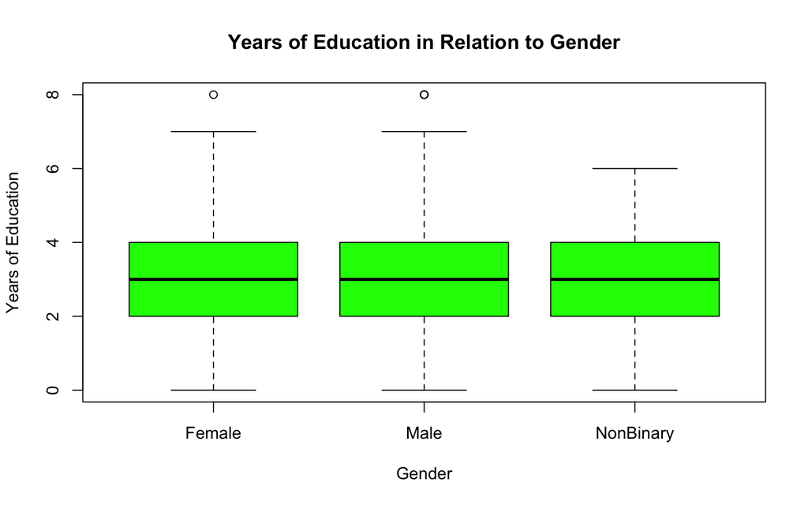

```r
boxplot(years_of_education ~ gender, d, col = "green", main = "Years of Education in Relation to Gender", xlab = "Gender", ylab = "Years of Education")
```